# Project Description - Bank Churn Prediction

## Bank Churn Prediction

### Objective:

Given a Bank customer, build a neural network-based classifier that can determine whether they will leave or not in the next 6 months.

### Context:

Businesses like banks that provide service have to worry about the problem of 'Churn' i.e. customers leaving and joining another service provider. It is important to understand which aspects of the service influence a customer's decision in this regard. Management can concentrate efforts on the improvement of service, keeping in mind these priorities.

### Data Description:

The case study is from an open-source dataset from Kaggle. The dataset contains 10,000 sample points with 14 distinct features such as CustomerId, CreditScore, Geography, Gender, Age, Tenure, Balance, etc.

Link to the Kaggle project site:https://www.kaggle.com/barelydedicated/bank-customer-churn-modeling

### Data Dictionary:

- RowNumber: Row number.
- CustomerId: Unique identification key for different customers.
- Surname: Surname of the customer
- Credit Score: Credit score is a measure of an individual's ability to pay back the borrowed amount. It is the numerical representation of their creditworthiness. A * credit score is a 3-digit number that falls in the range of 300-900, 900 being the highest.
- Geography: The country to which the customer belongs.
- Gender: The gender of the customer.
- Age: Age of the customer.
- Tenure: The period of time a customer has been associated with the bank.
- Balance: The account balance (the amount of money deposited in the bank account) of the customer.
- NumOfProducts: How many accounts, bank account affiliated products the person has.
- HasCrCard: Does the customer have a credit card through the bank?
- IsActiveMember: Subjective, but for the concept
- EstimatedSalary: Estimated salary of the customer.
- Exited: Did they leave the bank after all?

```python
import pandas as pd
import numpy as np
import matplotlib.pyplot as plt
import seaborn as sns

%matplotlib inline

import warnings
warnings.simplefilter("ignore")

pd.options.display.float_format = '{:,.2f}'.format
```

importing the data into a dataframe

```python
df = pd.read_csv('bank.csv')
df.shape
```

```
(10000, 14)
```

```python
df.head()
```

|  | RowNumber | CustomerId | Surname | CreditScore | Geography | Gender | Age | Tenure | Balance | NumOfProducts | HasCrCard | IsActiveMember | EstimatedSalary | Exited |
| --- | --- | --- | --- | --- | --- | --- | --- | --- | --- | --- | --- | --- | --- | --- |
| 0 | 1 | 15634602 | Hargrave | 619 | France | Female | 42 | 2 | 0.00 | 1 | 1 | 1 | 101,348.88 | 1 |
| 1 | 2 | 15647311 | Hill | 608 | Spain | Female | 41 | 1 | 83,807.86 | 1 | 0 | 1 | 112,542.58 | 0 |
| 2 | 3 | 15619304 | Onio | 502 | France | Female | 42 | 8 | 159,660.80 | 3 | 1 | 0 | 113,931.57 | 1 |
| 3 | 4 | 15701354 | Boni | 699 | France | Female | 39 | 1 | 0.00 | 2 | 0 | 0 | 93,826.63 | 0 |
| 4 | 5 | 15737888 | Mitchell | 850 | Spain | Female | 43 | 2 | 125,510.82 | 1 | 1 | 1 | 79,084.10 | 0 |

Three columns will not be necessary at first glance; 'RowNumber', 'Surname', and 'CustomerId'

```python
df.drop(columns=['RowNumber', 'Surname', 'CustomerId'], inplace=True)
df.head()
```

|  | CreditScore | Geography | Gender | Age | Tenure | Balance | NumOfProducts | HasCrCard | IsActiveMember | EstimatedSalary | Exited |
| --- | --- | --- | --- | --- | --- | --- | --- | --- | --- | --- | --- |
| 0 | 619 | France | Female | 42 | 2 | 0.00 | 1 | 1 | 1 | 101,348.88 | 1 |
| 1 | 608 | Spain | Female | 41 | 1 | 83,807.86 | 1 | 0 | 1 | 112,542.58 | 0 |
| 2 | 502 | France | Female | 42 | 8 | 159,660.80 | 3 | 1 | 0 | 113,931.57 | 1 |
| 3 | 699 | France | Female | 39 | 1 | 0.00 | 2 | 0 | 0 | 93,826.63 | 0 |
| 4 | 850 | Spain | Female | 43 | 2 | 125,510.82 | 1 | 1 | 1 | 79,084.10 | 0 |

Next, create dummy columns for the categorical features 'Geography' and 'Gender'

```python
df = pd.get_dummies(df, columns=['Geography', 'Gender'])
df.head()
```

|  | CreditScore | Age | Tenure | Balance | NumOfProducts | HasCrCard | IsActiveMember | EstimatedSalary | Exited | Geography_France | Geography_Germany | Geography_Spain | Gender_Female | Gender_Male |
| --- | --- | --- | --- | --- | --- | --- | --- | --- | --- | --- | --- | --- | --- | --- |
| 0 | 619 | 42 | 2 | 0.00 | 1 | 1 | 1 | 101,348.88 | 1 | 1 | 0 | 0 | 1 | 0 |
| 1 | 608 | 41 | 1 | 83,807.86 | 1 | 0 | 1 | 112,542.58 | 0 | 0 | 0 | 1 | 1 | 0 |
| 2 | 502 | 42 | 8 | 159,660.80 | 3 | 1 | 0 | 113,931.57 | 1 | 1 | 0 | 0 | 1 | 0 |
| 3 | 699 | 39 | 1 | 0.00 | 2 | 0 | 0 | 93,826.63 | 0 | 1 | 0 | 0 | 1 | 0 |
| 4 | 850 | 43 | 2 | 125,510.82 | 1 | 1 | 1 | 79,084.10 | 0 | 0 | 0 | 1 | 1 | 0 |

#### Bivariate Analysis

Let's use pairplot to view the relationships between all features

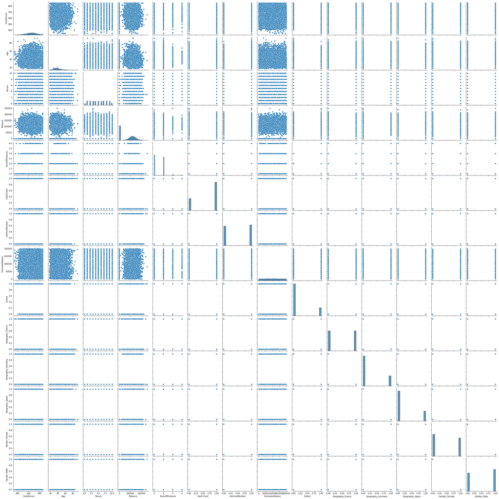

```python
sns.pairplot(df)
plt.show()
```

```python
df.drop(columns=['Gender_Male'], inplace=True)
```

```python
df.corr()[['Exited']].sort_values(by='Exited')
```

|  | Exited |
| --- | --- |
| IsActiveMember | -0.16 |
| Geography_France | -0.10 |
| Geography_Spain | -0.05 |
| NumOfProducts | -0.05 |
| CreditScore | -0.03 |
| Tenure | -0.01 |
| HasCrCard | -0.01 |
| EstimatedSalary | 0.01 |
| Gender_Female | 0.11 |
| Balance | 0.12 |
| Geography_Germany | 0.17 |
| Age | 0.29 |
| Exited | 1.00 |

- There does not seem to be a strong correlation between Exited and the features, with age having the highest correlation at 0.29

Next, I will make a list of the higher correlated features to test later if desired

```python
hc = [i for i in df.corr()[['Exited']].index if abs(df.corr()[['Exited']].loc[i].values[0]) >= 0.1]
hc.remove('Exited')
hc
```

```
['Age',
 'Balance',
 'IsActiveMember',
 'Geography_France',
 'Geography_Germany',
 'Gender_Female']
```

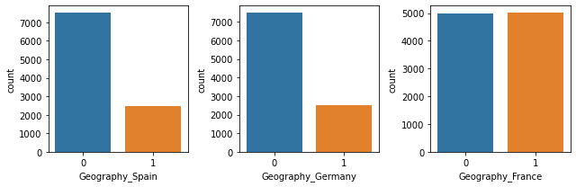

```
Percent of population in Geography_Spain: 24.77 %
Percent of population in Geography_Germany: 25.09 %
Percent of population in Geography_France: 49.86 %
```

```python
country = ['Geography_Spain', 'Geography_Germany', 'Geography_France']
n=1
plt.figure(figsize=(9,3), tight_layout=True)
for c in country:
    plt.subplot(1, 3, n)
    sns.countplot(df[c])
    n +=1
plt.show()

for c in country:
    print('Percent of population in {}:'.format(c), (df[c].value_counts().min()/df[c].value_counts().sum())*100, '%')
```

- as seen more clearly above, the location of customers is skewed towards France. We will keep this in mind as we continue with our analysis.

```python
exit = []
tot = []
ex_rat = []
for c in country:
    ex = df[df[c] == 1]['Exited'].sum()
    to = df[df[c] == 1]['Exited'].count()
    exit.append(ex)
    tot.append(to)
    ex_rat.append(round(ex/to, 2))
```

```python
country_exit = pd.DataFrame({'Country': country, '# of Exits': exit, 'Customers in Country': tot, 'Exit Ratio': ex_rat})
country_exit
```

|  | Country | # of Exits | Customers in Country | Exit Ratio |
| --- | --- | --- | --- | --- |
| 0 | Geography_Spain | 413 | 2477 | 0.17 |
| 1 | Geography_Germany | 814 | 2509 | 0.32 |
| 2 | Geography_France | 810 | 5014 | 0.16 |

- The bank has twice as many customers leaving that reside in Germany relative to each countries respective number of customers
- What if we plot each country vs. Balance?

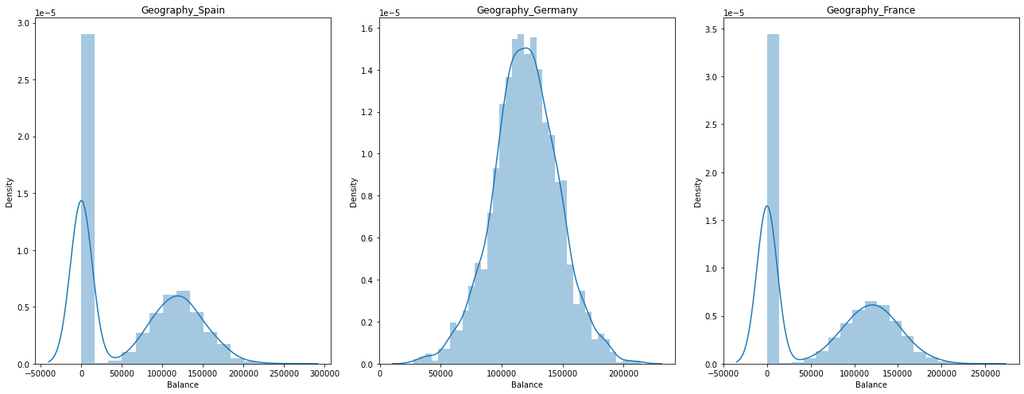

```python
# showing distribution of balances for each country

plt.figure(figsize=(18,7), tight_layout=True)
n=1
for c in country:
    plt.subplot(1,3,n)
    plt.title(c)
    sns.distplot(df[df[c]==1]['Balance'])
    n+=1
plt.show()
```

- This is intriguing as only the French and Spanish customers seem to have a large proportion of 0 balances, while German customers show a nearly perfect normal distribution. Let's look more into the 0 balances

We will compare the 0 balances with number of accounts per customer

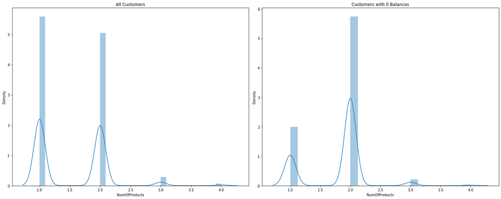

```python
plt.figure(figsize=(20,8), tight_layout=True)
plt.subplot(121)
sns.distplot(df['NumOfProducts'])
plt.title('All Customers')
plt.subplot(122)
sns.distplot(df[df['Balance'] == 0]['NumOfProducts'])
plt.title('Customers with 0 Balances')
plt.show()
```

- These plots show me that most customers with zero balances have at least 2 accounts which could explain the zero balance

What percent of our data has an account balance of zero?

```python
print('{}% of accounts have a balance of 0'.format((df[df['Balance']==0]['Balance'].count()/10000)*100))
```

```
36.17% of accounts have a balance of 0
```

- It may be worth considering dropping these 0 balances so they do not skew our model

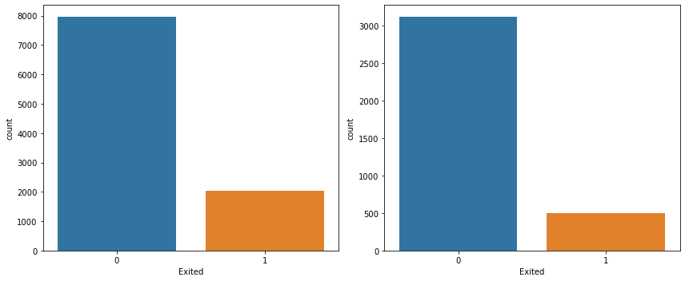

```python
plt.figure(figsize=(12,5), tight_layout=True)
plt.subplot(121)
sns.countplot(df['Exited'])
plt.subplot(122)
sns.countplot(df[df['Balance']==0]['Exited'])
plt.show()
```

- based on this brief analysis, we will keep zero value accounts in the data

#### Split the Data

```python
from sklearn.model_selection import train_test_split

x_cols = [c for c in list(df.columns) if c != 'Exited']

X = df[x_cols]
y = df['Exited']

X_train, X_test, y_train, y_test = train_test_split(X, y, test_size=0.25, random_state=14)
```

#### Scale the Data

```python
from sklearn.preprocessing import StandardScaler

scaler = StandardScaler().fit(X_train)

X_train = scaler.transform(X_train)
X_test = scaler.transform(X_test)

y_train = np.array(y_train)
y_test = np.array(y_test)
```

### Build the Neural Network

```python
from tensorflow.keras import Sequential
from tensorflow.keras.layers import Dense
from tensorflow.keras import optimizers

model = Sequential()

model.add(Dense(12, activation='relu', input_dim=12))
model.add(Dense(1, activation='sigmoid'))
```

```python
opt = optimizers.Adam(0.01)

model.compile(optimizer=opt, loss='binary_crossentropy', metrics=['accuracy'])
```

```python
epochs = 10
hist = model.fit(X_train, y_train, batch_size=1000, epochs=epochs, validation_split=0.25)

hist_df = pd.DataFrame(hist.history)
```

#### Metrics

```python
hist_df
```

|  | loss | accuracy | val_loss | val_accuracy |
| --- | --- | --- | --- | --- |
| 0 | 0.89 | 0.45 | 0.71 | 0.58 |
| 1 | 0.62 | 0.66 | 0.57 | 0.75 |
| 2 | 0.51 | 0.80 | 0.52 | 0.78 |
| 3 | 0.46 | 0.81 | 0.50 | 0.78 |
| 4 | 0.44 | 0.82 | 0.49 | 0.78 |
| 5 | 0.43 | 0.82 | 0.48 | 0.79 |
| 6 | 0.42 | 0.82 | 0.47 | 0.79 |
| 7 | 0.41 | 0.83 | 0.47 | 0.80 |
| 8 | 0.41 | 0.83 | 0.46 | 0.80 |
| 9 | 0.40 | 0.83 | 0.46 | 0.80 |

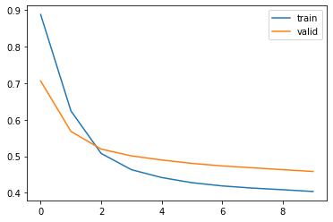

```python
import matplotlib.pyplot as plt

plt.plot(hist_df['loss'])
plt.plot(hist_df['val_loss'])
plt.legend(("train" , "valid") , loc =0)
plt.show()
```

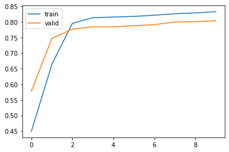

```python
import matplotlib.pyplot as plt

plt.plot(hist_df['accuracy'])
plt.plot(hist_df['val_accuracy'])
plt.legend(("train" , "valid") , loc =0)
plt.show()
```

```python
# Ryan - adding the 'return_dict' parameter to get the labels of the metrics
loss = model.evaluate(X_test, y_test, verbose=False, return_dict=True)
loss
```

```
{'loss': 0.41556957364082336, 'accuracy': 0.8220000267028809}
```

#### Predict the outcomes

```python
y_pred = np.round(model.predict(X_test))
```

```python
from sklearn.metrics import confusion_matrix
```

```python
y_pred = [y_pred[v][0] for v in range(y_pred.shape[0])]
y_pred = abs(np.array(y_pred))
```

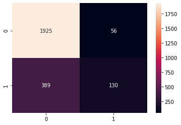

```python
sns.heatmap(confusion_matrix(y_test, y_pred), annot=True, fmt='g')
plt.show()
```

#### Conclusion

```python
from sklearn.metrics import classification_report as cr

print(cr(y_test, y_pred))
```

```
              precision    recall  f1-score   support

           0       0.83      0.97      0.90      1981
           1       0.70      0.25      0.37       519

    accuracy                           0.82      2500
   macro avg       0.77      0.61      0.63      2500
weighted avg       0.80      0.82      0.79      2500
```

- After running our model, the precision, recall, and f1-scores look good for predicting customers who will not leave the bank; However, the model does not do as good of a job predicting those who will in fact leave.
- Looking at the metrics for customers predicted to leave, the recall and f1-score ratios are very low at 0.25 and 0.37 respectively. Precision is okay but not great at 0.69.
- Based on accuracy, our model does improve across 10 epochs from 0.58 to 0.8
- Neural networks models are very powerful, but a model can only be as good as the features used to build it. The features we have here were not very highly correlated with customers exiting the bank. This could be one reason why our model returns low predictive scores for recall and f1 when trying to predict customers who will exit the bank.